# Preliminary results–NHS-Delay Feb 12

Author

Jane Lange

# Objective

- Examine the impact of a delay in diagnosis in clinically detected individuals on the outcomes of the NHS Galleri trial.
- Examine sensitivity of results to the length of delay.

# Methods

## NHS Trial Simulation

- We simulated 200 iterations of the trial.
- Each NHS-Galleri simulation includes N=70,020 participants in both the screening and control arms, followed for three annual screens plus one additional year of follow-up. Starting ages range from 50 to 77 years, assigned according to UK demographic tables(Northern Ireland Statistics And Research Agency 2022). The simulation permits censoring due to other-cause mortality but assumes no additional dropout.
- The trial was simulated using the **MCEDsim** package, which generates individual level natural histories according to a five-state model (Figure 1).
- Outcomes are simulated for 11 solid cancer sites (anus, bladder, colorectal, esophagus, gastric, head and neck, liver, lung, lymphoma,ovary, pancreas), corresponding to 11/12 cancers targeted in the NHS Galleri trial endpoints.
- For the NHS Galleri simulations, models are calibrated to National Cancer Registration and Analysis Service (NCRAS) data. [Need to rerun simulations with UK data–these results actually based on US data.]
- Other cause death is based on US mortality tables.

Figure 1: Five state natural history model used in MCEDsim.

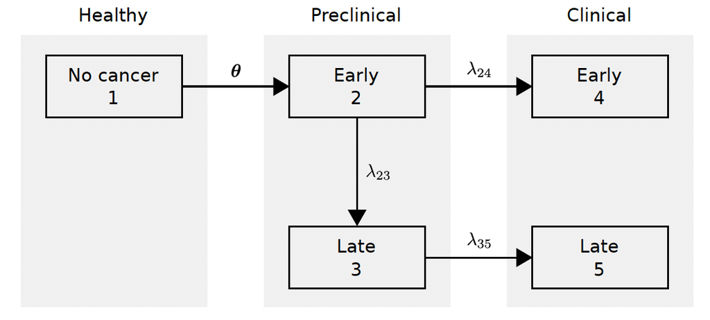

## Natural history and test performance inputs

- **MCEDsim** is calibrated to age- and stage-specific cancer incidence data based on two key inputs: the overall mean pre-clinical sojourn time (OMST) and the late-stage mean pre-clinical sojourn time (LMST).
- Natural history model and sensitivity inputs are specified as in (Gogebakan et al. 2025), which noted that the only existing study of pre-clinical detectability of the GRAIL demonstrated virtually no sensitivity beyond 2 years prior to clinical diagnosis(Patel et al. 2023).
- Sensitivity of the MCED test for each cancer site is set so that early-stage sensitivity is either equal to that observed in case-control studies (Klein et al. 2021) of clinically diagnosed patients (optimistic) or 50% of that level (conservative) (Table 1). Sensitivity for late-stage disease is assumed to be equal to that of clinically diagnosed patients. The three combinations of OMST, LMST, and early stage sensitivity assumptions are summarized in Table 2.

Table 1: Sensitivity of Galleri test based on case-control study (Klein et al. 2021)

| Site | Early | Late |
| --- | --- | --- |
| Anus | 0.50 | 1.00 |
| Bladder | 0.18 | 0.83 |
| Colorectal | 0.67 | 0.92 |
| Esophagus | 0.48 | 0.97 |
| Gastric | 0.33 | 0.94 |
| Head and neck | 0.72 | 0.93 |
| Liver | 0.94 | 1.00 |
| Lung | 0.40 | 0.93 |
| Lymphoma | 0.46 | 0.66 |
| Ovary | 0.60 | 0.90 |
| Pancreas | 0.62 | 0.88 |

Table 2: Simulation input scenarios.

| Assumption | OMST | LMST | Relative.Early.Stage.Sensitivity |
| --- | --- | --- | --- |
| Fast-fast-optimistic | 1 year | 6 months | 100% |
| Slow-fast-conservative | 2 years | 6 months | 50% |
| Slow-slow-conservative | 2 years | 1 year | 50% |

## Reporting results

- We report counts of early-stage (I-II) and late-stage disease detected at the end of the trial for screen- and clinically-detected cancers for the range of delay scenarios (0-.6 years).
- We also report the absolute and relative reduction in late- stage disease in the screen and control arms.
- Current results are based on outcomes observed within the trial (i.e., censored by the end of the trial).

# Results

- Under diagnostic delays in clinically diagnosed patients
  - Overall number of clinically detected cases observed during the trial goes down (Figure 2)
  - Counts of clinically diagnosed cancers in late-stage disease increase, and early-stage cancers decrease.
  - Counts of screen-detected cases are unaffected.

Figure 2: Mean counts of cases detected by screen and control arm during simulated NHS-Galleri trials by diagnosis delay applied to clinically detected cases.

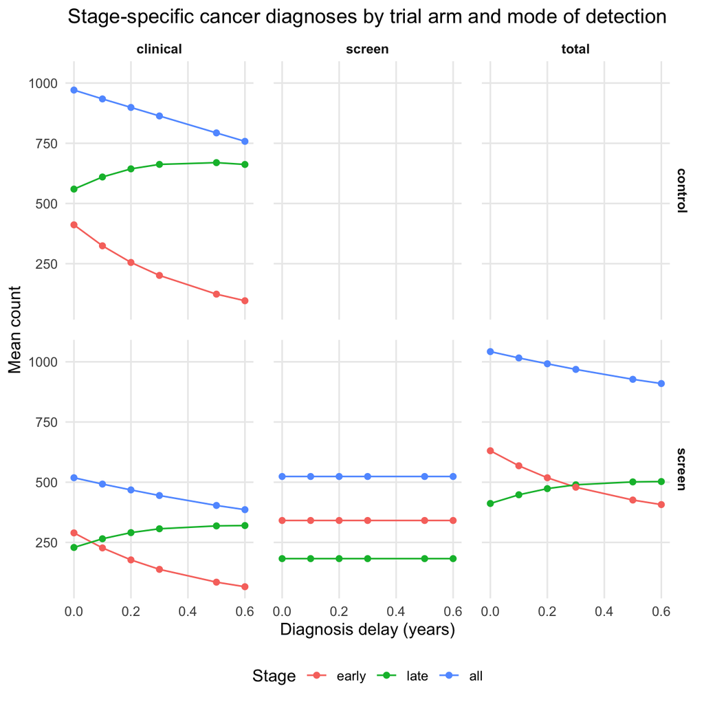

- Despite the fact that late-stage cases increase in both the screen and control arms with delayed diagnosis, the screen arm increases are proportionally greater.
- Thus, the relative reduction in late-stage disease tends to decrease with increasing delay
  - This pattern is likely due to the fact that in our simulation, in absence of a delay in diagnosis, early-stage disease is relatively more abundant in interval cancers (55%) than in clinically diagnosed cases in the control arm (43%). Thus, under diagnostic delays, more early-stage cases screen arm are subject to transitioning to late-stage disease by the time they are detected.

Figure 3: Mean absolute and relative reductions in late-stage disease across 200 simulated NHS-Galleri trials as a function of diagnostic delay among clinically detected cases.

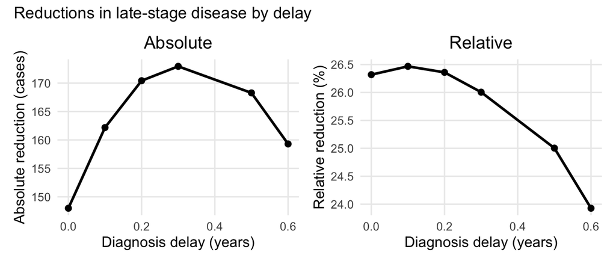

## Open questions

- How do we want to consider extended follow-up?
  - Of those cancers that are diagnosed within the trial, project final disease stage after X years of follow-up.
  - Assume trial is extended by X years, spillover effects continue, and project late-stage disease for all diagnosed within the full extended time frame.

## Next steps

- Rerun trial simulation using UK natural history models.
- Generate results for extended follow-up.
- Incorporate mortality outcomes?
- Rerun results for different natural history assumptions.
- Allow early-to-late transition rate to vary by cancer site.

## References

Gogebakan, Kemal Caglar, Jane Lange, Lukas Owens, Amalie Pinderup, Roman Gulati, Larry G. Kessler, Georgios Lyratzopoulos, and Ruth Etzioni. 2025. “Clinical Significance of a Multicancer Screening Trial With Stage-Based End Points.” *JAMA Network Open* 8 (10): e2536247. https://doi.org/10.1001/jamanetworkopen.2025.36247.

Klein, E. A., D. Richards, A. Cohn, M. Tummala, R. Lapham, D. Cosgrove, G. Chung, et al. 2021. “Clinical Validation of a Targeted Methylation-Based Multi-Cancer Early Detection Test Using an Independent Validation Set.” *Annals of Oncology : Official Journal of the European Society for Medical Oncology* 32 (9): 1167–77. https://doi.org/10.1016/j.annonc.2021.05.806.

Northern Ireland Statistics And Research Agency. 2022. “2021 Census Aggegate Data First Release(Data Downloaded: May 2022).” Northern Ireland Statistics; Research Agency. https://doi.org/10.5257/CENSUS/AGGREGATE-2021-1.

Patel, Alpa, Christina A. Clarke Dur, Gregory Alexander, Emily L Deubler, Eric T. Fung, Roger Jiang, Cari Lichtman, et al. 2023. “Methylated DNA Biomarkers and Incident Cancer in the American Cancer Society (ACS) Cancer Prevention Study-3 (CPS-3) Cohort.” *Journal of Clinical Oncology* 41 (16_suppl): 3004–4. https://doi.org/10.1200/JCO.2023.41.16_suppl.3004.